# Appendix.A

```r
g.yx=function(xp,x,params) {
dnorm(xp,
mean=params$growth.int+params$growth.slope*x+params$growth.sqrd*x^2,
sd=sqrt(params$growth.sigma2*exp(2*params$growth.sigma2.exp*x)))
}
```

We rerun the code to build the matrix to obtain lambda, sensitivies, and elasticities.

```r
G=h*outer(y,y,g.yx,params=params) # growth matrix
S=s.x(y,params=params) # survival
P=G # placeholder; redefine P on the next line
# fix eviction of offspring
for(i in 1:(n/2)) {
G[1,i]<-G[1,i]+1-sum(G[,i])
P[,i]<-G[,i]*S[i]
}
# fix eviction of large adults
for(i in (n/2+1):n) {
G[n,i]<-G[n,i]+1-sum(G[,i])
P[,i]<-G[,i]*S[i]
}

F=h*outer(y,y,f.yx,params=params) # reproduction matrix
K=P+F # full matrix
(lam=Re(eigen(K)$values[1])) # new population growth rat
```

```
## [1] 0.9835344
```

```r
w.eigen=Re(eigen(K)$vectors[,1])
stable.dist=w.eigen/sum(w.eigen)
v.eigen=Re(eigen(t(K))$vectors[,1])
repro.val=v.eigen/v.eigen[1]
v.dot.w=sum(stable.dist*repro.val)*h
sens=outer(repro.val,stable.dist)/v.dot.w
elas=matrix(as.vector(sens)*as.vector(K)/lam,nrow=n)
```

The new model prevents individuals from growing continuously and sets an (asymptotic) upper limit on size where the growth regression crosses the 1:1 line. Because individuals cannot grow continuously in the model, there is now more mass in the “adult” portion of the stable stage distribution (sizes > 4), because there are no longer very large individuals in the population, who previously were producing a very large number of offspring in the model. Not surprisingly, there is slightly greater sensitivity/elasticity to survival of individuals reaching sizes near 6, corresponding to the largest individuals in the current model.

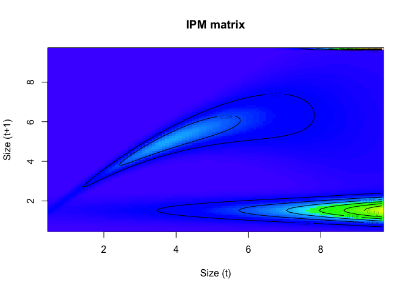

```r
image(y,y,t(K), xlab="Size (t)",ylab="Size (t+1)",
col=topo.colors(100), main="IPM matrix")
contour(y,y,t(K), add = TRUE, drawlabels = TRUE)
```

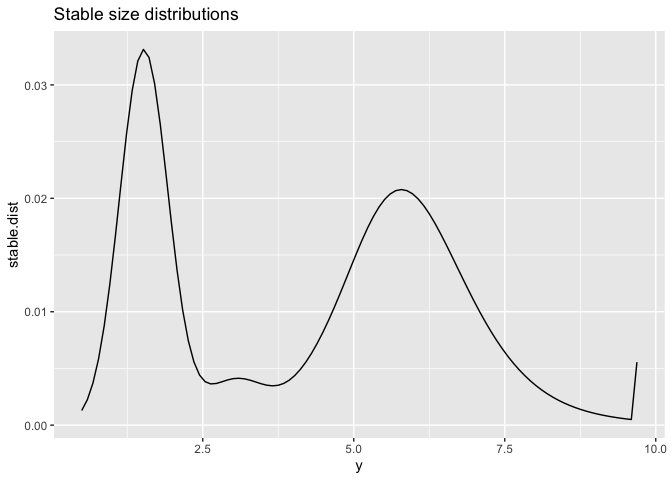

```r
ggplot(data = cbind(y,stable.dist), aes(x = y, y = stable.dist))+
  geom_line()+
  ggtitle("Stable size distributions")
```

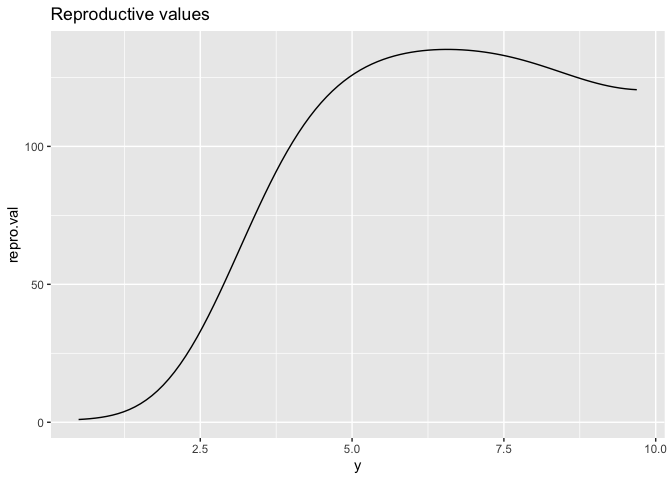

```r
ggplot(data = cbind(y,repro.val), aes(x = y, y = repro.val))+
  geom_line()+
  ggtitle("Reproductive values")
```

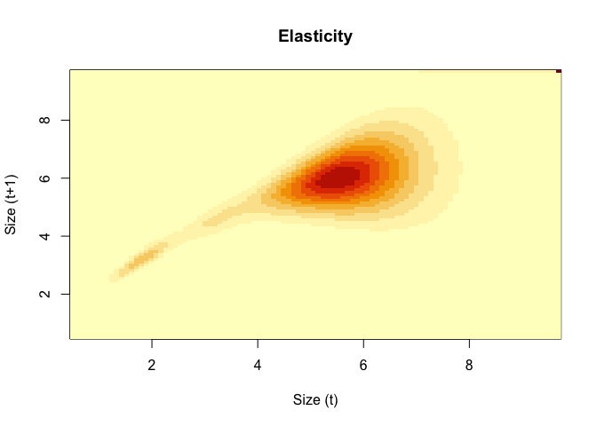

```r
image(y,y,t(elas),xlab="Size (t)",ylab="Size (t+1)",main="Elasticity")
```

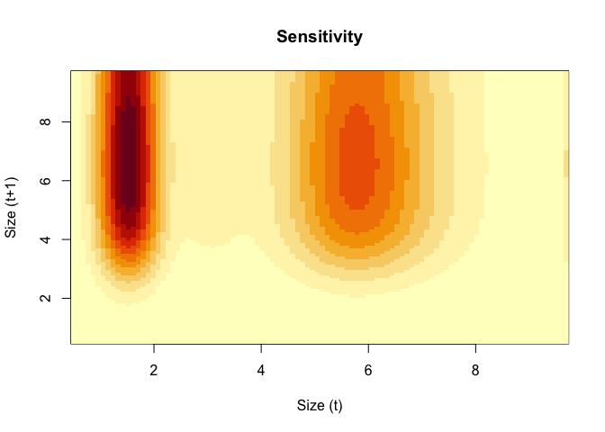

```r
image(y,y,t(sens),xlab="Size (t)",ylab="Size (t+1)", main="Sensitivity")
```

Flowering Probability: Two issues at play. One is that we know the biology and expect larger individuals to flower more. The other is that the data don’t support the form of the original model. More generally, it is not a good idea to combine multiple processes into a single function, as this makes it hard to model the data. Consider the case where the plant does not flower each year, perhaps dependent on stress deriving from some environmental factor. We expect that larger plants are more likely to flower because they can maintain a sufficient amount of stored resources to buffer against environmental variation. We might not know what triggers the decision to flower, but we can at least describe its size dependence by including the probability of flowering in the model. The flowering probability function will enter the reproduction kernal (called f.xy()). The version of f.xy() used above simply assumes that all plants flower, so including the flowering probability function will reduce this number. Including a flowering probability in the model requires 5 steps.

1. Write the flowering probability function. Most easily modeled using logistic regression.

```r
p.flower.x=function(x,params) {
u=exp(params$flower.int+params$flower.slope*x)
return(u/(1+u))
}
```

2. Modify the reproduction function (f.xy) to include the flowering probability function. This just amounts to mulitplying the argument in f.xy by p.flower.x

```r
f.yx=function(xp,x,params) {
p.flower.x(x,params)*
params$establishment.prob*
dnorm(xp,mean=params$recruit.size.mean,sd=params$recruit.size.sd)*
exp(params$seed.int+params$seed.slope*x)
}
```

3. Fit a logistic regression for flowering probability

```r
flower.reg=glm(fec.flower~size,data=d,family=binomial())
summary(flower.reg)
```

```
##
## Call:
## glm(formula = fec.flower ~ size, family = binomial(), data = d)
##
## Deviance Residuals:
##      Min        1Q    Median        3Q       Max
## -2.90763   0.05881   0.16048   0.39906   1.94232
##
## Coefficients:
##             Estimate Std. Error z value Pr(>|z|)
## (Intercept)  -6.5495     0.9564  -6.848 7.48e-12 ***
## size          1.9081     0.2465   7.740 9.92e-15 ***
## ---
## Signif. codes:  0 '***' 0.001 '**' 0.01 '*' 0.05 '.' 0.1 ' ' 1
##
## (Dispersion parameter for binomial family taken to be 1)
##
##     Null deviance: 285.68  on 279  degrees of freedom
## Residual deviance: 144.30  on 278  degrees of freedom
##   (220 observations deleted due to missingness)
## AIC: 148.3
##
## Number of Fisher Scoring iterations: 6
```

```r
params$flower.int=coefficients(flower.reg)[1]
params$flower.slope=coefficients(flower.reg)[2]
```

4. Update the regression for seed number to include only the individuals that flowered

```r
seed.reg=glm(fec.seed~size,data=d[d$fec.flower==1,],family=poisson())
summary(seed.reg)
```

```
##
## Call:
## glm(formula = fec.seed ~ size, family = poisson(), data = d[d$fec.flower ==
##     1, ])
##
## Deviance Residuals:
##      Min        1Q    Median        3Q       Max
## -2.54532  -0.76716   0.03013   0.66809   2.98617
##
## Coefficients:
##             Estimate Std. Error z value Pr(>|z|)
## (Intercept)  2.85617    0.07447  38.353  < 2e-16 ***
## size         0.05076    0.01370   3.706  0.00021 ***
## ---
## Signif. codes:  0 '***' 0.001 '**' 0.01 '*' 0.05 '.' 0.1 ' ' 1
##
## (Dispersion parameter for poisson family taken to be 1)
##
##     Null deviance: 250.71  on 221  degrees of freedom
## Residual deviance: 236.90  on 220  degrees of freedom
##   (220 observations deleted due to missingness)
## AIC: 1339
##
## Number of Fisher Scoring iterations: 4
```

```r
params$seed.int=coefficients(seed.reg)[1]
params$seed.slope=coefficients(seed.reg)[2]
```

5. Rerun code to obtain lambda, sensitivites, and elasticities. Note that lambda decreases slighly because fewer individuals reproducce.

```r
G=h*outer(y,y,g.yx,params=params) # growth matrix
S=s.x(y,params=params) # survival
P=G # placeholder; redefine P on the next line
# fix eviction of offspring
for(i in 1:(n/2)) {
G[1,i]<-G[1,i]+1-sum(G[,i])
P[,i]<-G[,i]*S[i]
}
# fix eviction of large adults
for(i in (n/2+1):n) {
G[n,i]<-G[n,i]+1-sum(G[,i])
P[,i]<-G[,i]*S[i]
}
F=h*outer(y,y,f.yx,params=params) # reproduction matrix
K=P+F # full matrix
(lam=Re(eigen(K)$values[1])) # new population growth rate
```

```
## [1] 0.9765733
```

```r
w.eigen=Re(eigen(K)$vectors[,1])
stable.dist=w.eigen/sum(w.eigen)
v.eigen=Re(eigen(t(K))$vectors[,1])
repro.val=v.eigen/v.eigen[1]
v.dot.w=sum(stable.dist*repro.val)*h
sens=outer(repro.val,stable.dist)/v.dot.w
elas=matrix(as.vector(sens)*as.vector(K)/lam,nrow=n)
```

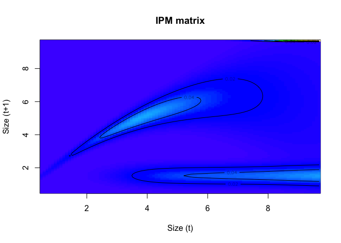

```r
image(y,y,t(K), xlab="Size (t)",ylab="Size (t+1)",
col=topo.colors(100), main="IPM matrix")
contour(y,y,t(K), add = TRUE, drawlabels = TRUE)
```

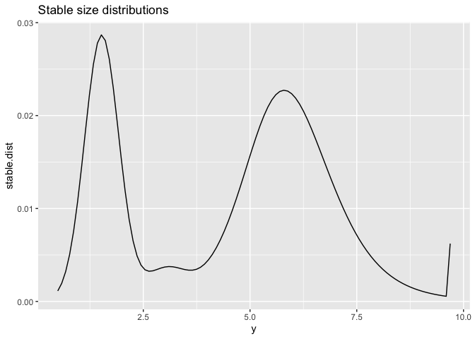

```r
ggplot(data = cbind(y,stable.dist), aes(x = y, y = stable.dist))+
  geom_line()+
  ggtitle("Stable size distributions")
```

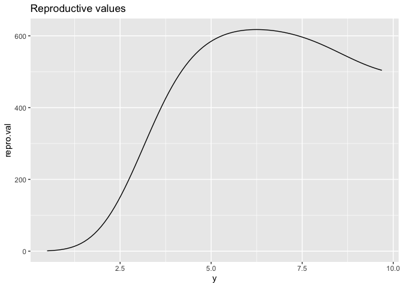

```r
ggplot(data = cbind(y,repro.val), aes(x = y, y = repro.val))+
  geom_line()+
  ggtitle("Reproductive values")
```

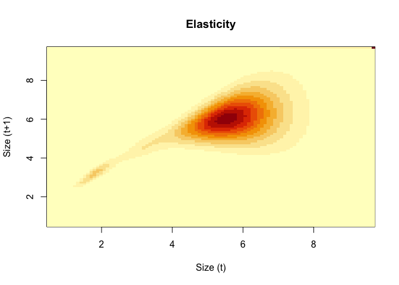

```r
image(y,y,t(elas),xlab="Size (t)",ylab="Size (t+1)",main="Elasticity")
```

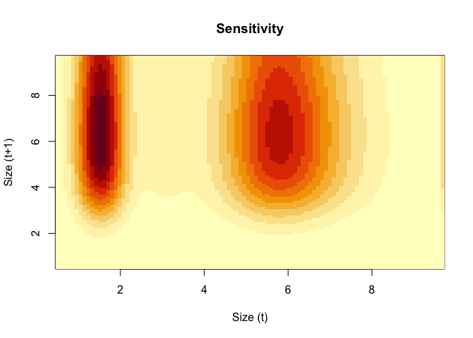

```r
image(y,y,t(sens),xlab="Size (t)",ylab="Size (t+1)", main="Sensitivity")
```

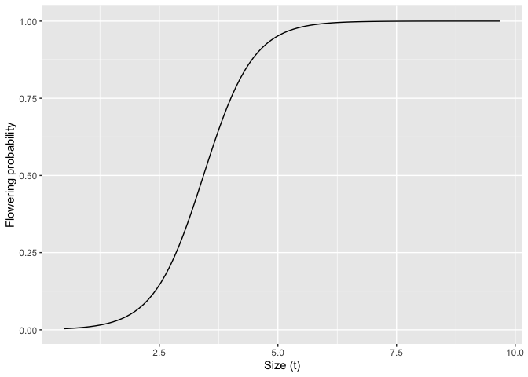

```r
ggplot(data = as.data.frame(cbind(y,predict(flower.reg, newdata = data.frame(size=y), type="response"))), aes(x = y, y = V2))+
  geom_line()+
  xlab("Size (t)")+
  ylab("Flowering probability")
```

## Diagnostics

How to calculate some of the diagnostics for the kernel discussed in this section.